# Did Rexburg run out of snow?

Winter 2025-2026 was very peculiar. Many people in Rexburg Idaho made the warmer weather a topic for small talk. Many were disappointed in the lack of snow. The locals were very adamant that this is quite rare for Rexburg, sometimes dubbed as “The Iceburg.” This analysis seeks to investigate whether this year’s winter temperatures were significantly different from other year’s winters, or if the peculiarity is over-exaggerated.

```r
rexburg <- get_GSOD(
  years   = 2000:2025,
  station = "726818-94194")
```

```r
rexburg <- rexburg %>%
  select(NAME, YEAR, MONTH, DAY, YDAY, TEMP) %>%
  filter(YEAR <2025)

rexburg2026 <- read.csv("../../Data/rexburg2026.csv")

rexburg2026 <- rexburg2026 %>%
  select(NAME = Station_name, DATE, TEMP = temperature) %>%
  mutate(
    DATE = ymd_hms(DATE),
    YEAR = year(DATE),
    MONTH = month(DATE),
    DAY = day(DATE),
    YDAY = yday(DATE)
  ) %>%
  group_by(NAME, YEAR, MONTH, DAY, YDAY) %>%
  summarise(
    TEMP = mean(TEMP, na.rm = TRUE),
    .groups = "drop"
  )

rexburg2025 <- read.csv("../../Data/rexburg_2025.csv") %>%
  select(NAME = Station_name, DATE, TEMP= temperature) %>%
  mutate(
    DATE = ymd_hms(DATE),
    YEAR = year(DATE),
    MONTH = month(DATE),
    DAY = day(DATE),
    YDAY =yday(DATE)
  ) %>%
  group_by(NAME, YEAR, MONTH, DAY, YDAY) %>%
  summarise(
    TEMP = mean(TEMP, na.rm = TRUE),
    .groups = "drop"
  )

rdf <- bind_rows(rexburg,rexburg2025,rexburg2026)

rdf$TEMP <- (rdf$TEMP * 9/5) + 32
```

```r
rdf <- rdf %>%
  filter(MONTH %in% c(11, 12, 1, 2, 3)) %>%
  mutate(
    recentwinter = case_when(
      YEAR == 2025 & MONTH %in% c(11, 12) ~ 1,
      YEAR == 2026 & MONTH %in% c(1, 2, 3) ~ 1,
      TRUE ~ 0
    )
  )

rdf <- rdf %>%
  mutate(
    winteryear = case_when(
      MONTH %in% c(11, 12) ~ YEAR,
      MONTH %in% c(1, 2, 3) ~ YEAR - 1
    )
  ) %>%
  arrange(winteryear, YEAR, MONTH, DAY) %>%
  group_by(winteryear) %>%
  mutate(
    wdays = row_number()
  ) %>%
  ungroup() %>%
  filter(wdays <118)
```

## The Data

### Hide Table

This data is taken from weather information taken from the Rexburg Madison County Airport. It shows data spanning 25 years. This specific dataset has been filtered to only show temperature observations during the winter season. Due to dataset constraints for the most recent winter, the winter season has been constrained to span from November 1 - February 25 for each year.

### Show Table

```r
datatable(rdf)
```

|  | NAME | YEAR | MONTH | DAY | YDAY | TEMP | recentwinter | winteryear | wdays |
| --- | --- | --- | --- | --- | --- | --- | --- | --- | --- |
| 1 | REXBURG-MADISON COUNTY APT | 2000 | 1 | 1 | 1 | 19.76 | 0 | 1999 | 1 |
| 2 | REXBURG-MADISON COUNTY APT | 2000 | 1 | 2 | 2 | 19.94 | 0 | 1999 | 2 |
| 3 | REXBURG-MADISON COUNTY APT | 2000 | 1 | 3 | 3 | 16.16 | 0 | 1999 | 3 |
| 4 | REXBURG-MADISON COUNTY APT | 2000 | 1 | 4 | 4 | 21.74 | 0 | 1999 | 4 |
| 5 | REXBURG-MADISON COUNTY APT | 2000 | 1 | 5 | 5 | 22.46 | 0 | 1999 | 5 |
| 6 | REXBURG-MADISON COUNTY APT | 2000 | 1 | 6 | 6 | 18.32 | 0 | 1999 | 6 |
| 7 | REXBURG-MADISON COUNTY APT | 2000 | 1 | 7 | 7 | 15.44 | 0 | 1999 | 7 |
| 8 | REXBURG-MADISON COUNTY APT | 2000 | 1 | 8 | 8 | 20.48 | 0 | 1999 | 8 |
| 9 | REXBURG-MADISON COUNTY APT | 2000 | 1 | 9 | 9 | 20.48 | 0 | 1999 | 9 |
| 10 | REXBURG-MADISON COUNTY APT | 2000 | 1 | 10 | 10 | 26.06 | 0 | 1999 | 10 |

[output cut: 2915 more lines]

## The Model

A multiple regression model was applied to the data to fit 2 regression lines, one for the recent winter and another for the average of all previous winters. The model is as follows:

$$\underbrace{Y_i}_{\text{temperature}} =
\overbrace{\beta_0 + \beta_1 \underbrace{X_{i1}}_{\text{Previous Winter
(days)}}}^{\text{Previous Winter}} + \overbrace{\beta_2
\underbrace{X_{i2}}_{\text{1 if recent winter}} + \beta_3
\underbrace{X_{i1} X_{i2}}_{\text{Interaction}}}^{\text{Recent Winter
Adjustments to Line}} + \epsilon_i$$

## Hypothesis Tests

### Test for Equal y-Intercepts

$$H_0: \beta_2 = 0 \quad \text{(Equal
average temperature at start of season)} \\
H_a: \beta_2 \neq 0 \quad \text{(Non-equal average temperature at
start of season)}$$

### Test for Equal Slopes

$$H_0: \beta_3 = 0 \quad \text{( The
recent winter has the same average temperature trend as previous
winters.)} \\
H_a: \beta_3 \neq 0 \quad \text{(The recent winter has a different
temperature trend than previous winters.)}$$

## The Results

```r
lm.rwinter <- lm(TEMP ~ wdays + as.factor(recentwinter) + wdays:as.factor(recentwinter), data = rdf)
```

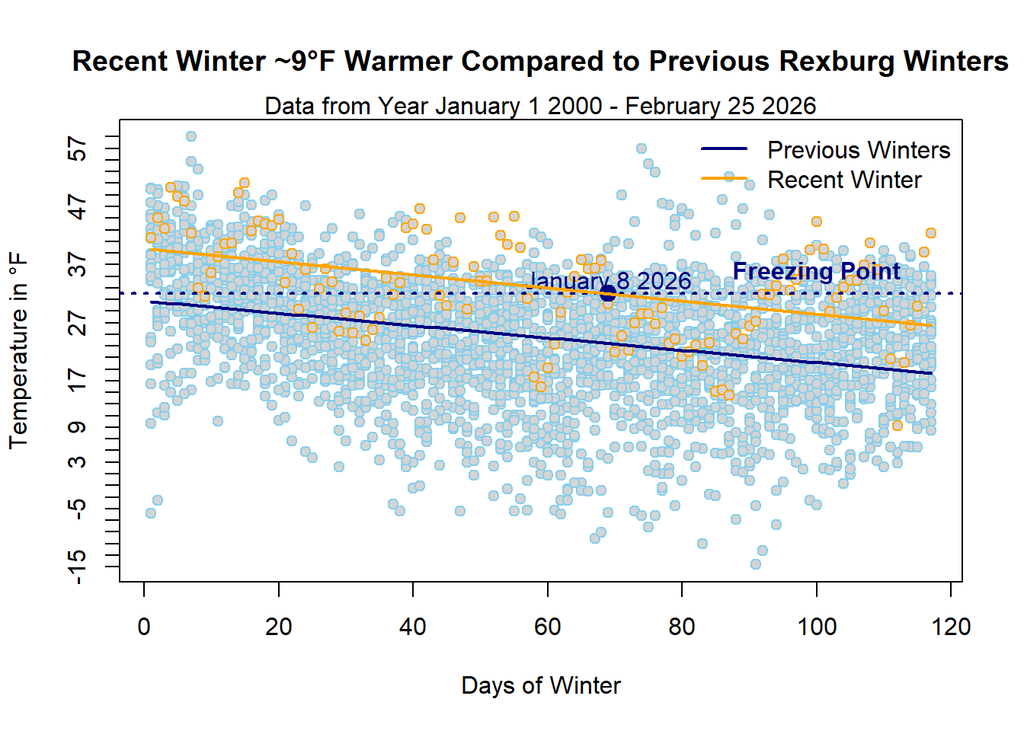

```r
plot(TEMP ~ wdays, data = rdf,
     col = c("skyblue", "orange")[as.factor(rdf$recentwinter)],
     pch = 21, bg = "gray83",
     yaxt = "n",
     xlab = "Days of Winter",
     ylab = "Temperature in °F"
    )
    title(main = "Recent Winter ~9°F Warmer Compared to Previous Rexburg Winters")
    mtext("Data from Year January 1 2000 - February 25 2026")

axis(2, at = seq(floor(min(rdf$TEMP, na.rm = TRUE)),
                 ceiling(max(rdf$TEMP, na.rm = TRUE)),
                 by = 2))

abline(h = 32, col = "navy", lty = 3, lwd = 2)
text(x = 100,
     y = 32,
     labels = "Freezing Point",
     col = "navy",
     pos = 3,
     font = 2)
points(x = 69, y = 32, pch = 19, col = "navy", cex = 1.5)
text(x = 69, y = 34, labels = "January 8 2026", col = "navy")

b <- coef(lm.rwinter)

curve(b[1] + b[2]*x, col="navy", lwd=2, add=TRUE)  #baseline (in blue)
curve((b[1] + b[3]) + (b[2] + b[4])*x, col="orange", lwd=2, add=TRUE) #changed line (in orange)

legend("topright",
       legend = c("Previous Winters", "Recent Winter"),
       col = c("navy", "orange"),
       lwd = 2,
       bty = "n")
```

```r
summary(lm.rwinter) %>%
  pander(title = "Regression Summary output for Temperature Across Winter Season")
```

|  | Estimate | Std. Error | t value | Pr(>\|t\|) |
| --- | --- | --- | --- | --- |
| **(Intercept)** | 30.76 | 0.3679 | 83.63 | 0 |
| **wdays** | -0.1061 | 0.005532 | -19.19 | 2.284e-77 |
| **as.factor(recentwinter)1** | 8.946 | 1.862 | 4.803 | 1.638e-06 |
| **wdays:as.factor(recentwinter)1** | -0.006534 | 0.02742 | -0.2383 | 0.8117 |

Fitting linear model: TEMP ~ wdays + as.factor(recentwinter) + wdays:as.factor(recentwinter)

| Observations | Residual Std. Error | $R^2$ | Adjusted $R^2$ |
| --- | --- | --- | --- |
| 2925 | 9.811 | 0.1381 | 0.1372 |

## Linear Regression Table Analysis

From this table we can see 4 estimated model coefficients, to be able to answer our hypothesis question, we need to look at the:

*“as.factor(recentwinter)” coefficient*, also known as the intercept value difference of the recent winter and previous winter, which is showing to be 8.946℉ higher than the previous winter. Because the probability of getting a result as extreme as 8.94℉ is at (P-value = 1.638e-06) we reject the null hypothesis that the average temperature of this winter at the start of the season is statistically equal to the average temperature at the start of the season for other winters.

*“wdays:as.factor(recentwinter)” coefficient*, also known as the difference of the slope of the previous winters and the recent winter. The estimate is showing a -0.006534 difference and a p-value of (p-value = 0.8117). Because our $\alpha = 0.05$, we fail to reject the null hypothesis, thus indicating that the rate of temperature drop is the same as previous winters.

## Checking Assumptions

The tests below show that the results of this analysis may be questionable. The residuals vs fitted plot show signs of non linearity and show that the variance of the error terms may not be constant. The qqPlot also has a lot of values that are outside of the line signifying that the error terms may not be normally distributed. The error terms seem to be independent as shown in the residuals vs order plot, but overall, we have to take the results of the analysis with a grain of salt

```r
par(mfrow=c(1,3))
plot(lm.rwinter, which=1)
qqPlot(lm.rwinter$residuals)
```

```
## [1] 1549 2548
```

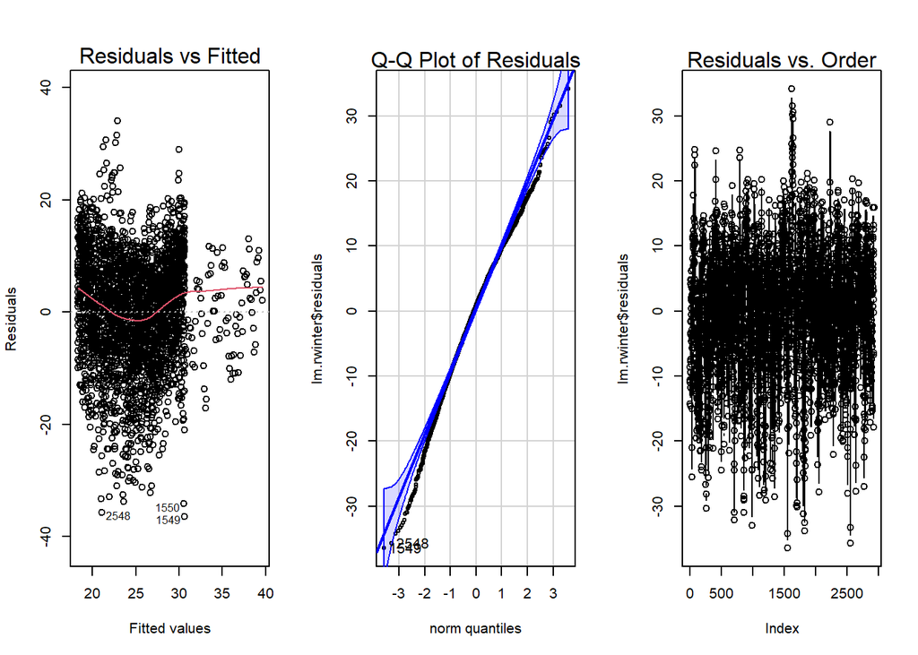

```r
mtext(side=3,text="Q-Q Plot of Residuals")
plot(lm.rwinter$residuals, type="b")
mtext(side=3, text="Residuals vs. Order")
```